# Combinations of Uncertain Numbers

### Review

Last week we discussed [bootstrapping and uncertainty](https://remiller1450.github.io/tut23/boot.html). The main idea was that data, and estimates derived from it, come with uncertainty, and we can use *simulation* (drawing bootstrap samples) to better understand the uncertainty present in our data.

There are several ways that we can incorporate uncertainty into our decision making:

1. Visually inspecting a bootstrap distribution
2. Finding the standard error of our estimate
3. Constructing a confidence interval

Things become more complicated as we become interested in *combinations of uncertain numbers*.

$~$

### Introduction

A **random variable** is a *variable* that represents the *unknown outcome* of a *random process*.

For example, suppose you’re a venture capitalist and can invest in an film to share in part of it’s profits. You might use the random variable $X$ to denote amount you get back for each $100,000 invested into the film.

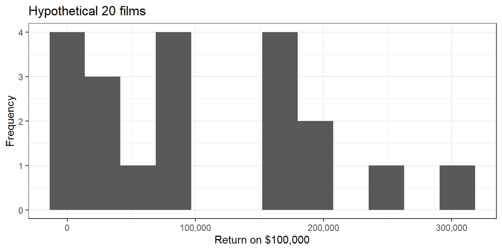

Any random variable has a *probability distribution*, which reflects likelihood of observing a particular value. We might see the data displayed above and conjecture that the return of $X$ looks like an [exponential distribution](https://en.wikipedia.org/wiki/Exponential_distribution) (with rate parameter $\lambda = 1$), potentially yielding the following *probability model*:

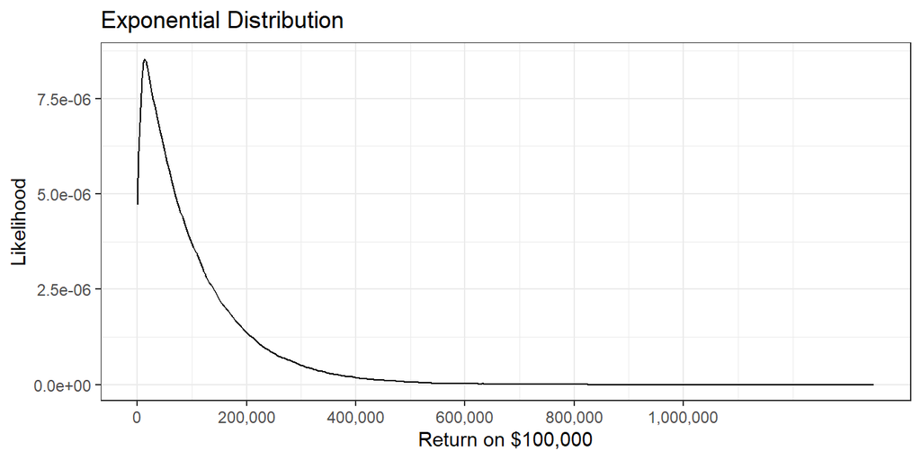

Using this model, we might ask ourselves two questions:

1. What’s the likelihood we lose money on the investment? or $Pr(X < 100,000)$
2. What’s the **expected value** of the investment? or $\text{Mean}(X)$

$~$

### How does this relate to simulation?

While the exponential curve displayed in the previous section reflects a probability distribution, which is a mathematical function, it was actually graphed using the following computer code:

```r
x = 100000*rexp(rate = 1, n = 200000)
ggplot() + geom_density(aes(x))
```

All this code did was randomly sample from the *exponential distribution*, with rate parameter $\lambda = 1$, a total of 200,000 times.

We can use these simulated samples to answer the questions we had posed earlier, without needing to rely on any complicated mathematics:

```r
## This is the expected value
mean(x)
```

```
## [1] 100077.8
```

```r
## This is the chances of losing money
sum(x <= 100000)/length(x)
```

```
## [1] 0.630415
```

It’s worth pointing out that the actual expected value of this model is exactly $100,000; the deviation we see is due to something known as *Monte Carlo error*, and we could reduce it by generating more samples.

- **Question**: Considering the expected value and probability of losing money, would you choose to invest in a film?

However, what if things followed the example given in *The Flaw of Averages*, and the films of interest had an *average profit* of $20,000,0000 (which would be shared proportionally with you as an investor) and a 25% chance of losing money?

- **Question**: Would you choose to invest in a film under these circumstances?

$~$

### Diversification

In reality it’s unlikely that you’re constrained to being able to only invest in a *single film*. So what if you spread your investment evenly across two films?

```r
x = 50000*rexp(rate = 1, n = 200000) + 50000*rexp(rate = 1, n = 200000)

## chances of losing money
sum(x <= 100000)/length(x)
```

```
## [1] 0.59326
```

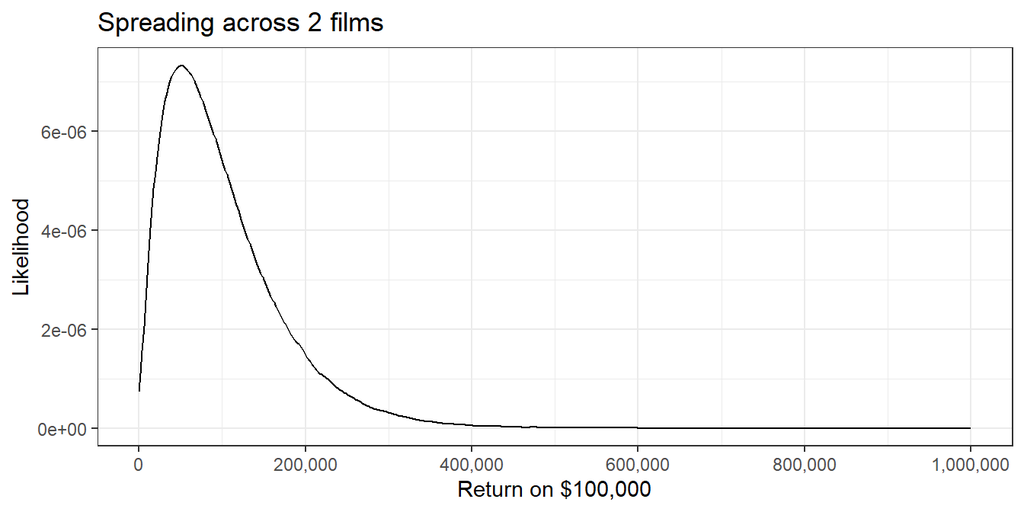

Now, what if you spread your investment across 5 films:

```r
x = 20000*rexp(rate = 1, n = 200000) +
    20000*rexp(rate = 1, n = 200000) +
    20000*rexp(rate = 1, n = 200000) +
    20000*rexp(rate = 1, n = 200000) +
    20000*rexp(rate = 1, n = 200000)

## chances of losing money
sum(x <= 100000)/length(x)
```

```
## [1] 0.55942
```

[figure not shown]

The benefit of *diversification* is that a return closer to the expected becomes more likely. This is due to a phenomenon known as **Central Limit theorem**. Copied below is a GIF animation of the example used in *The Flaw of Averages*:

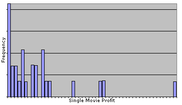

$~$

### Conclusion

This material was intended to provide a brief overview of a few core topics in probability, statistics, and decision making. It should be complimentary to our reading of The Flaw of Averages.

**Assignment**: To receive completion credit for participating in class today, you are expected to turn in a 3-5 sentence paragraph summarizing *the single main idea* of this material and what you conclude from it. Your focus in this paragraph should be clarity, conciseness, and technical accuracy.